# Least squares estimation of regression lines

Regression via least squares

Brian Caffo, Jeff Leek and Roger Peng

## General least squares for linear equations

Consider again the parent and child height data from Galton

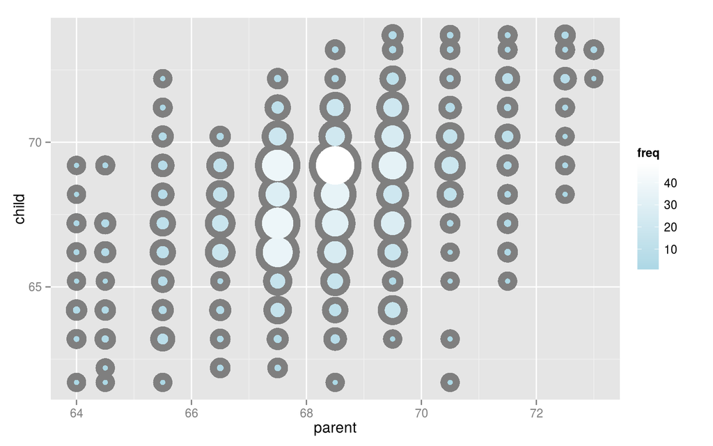

## Fitting the best line

- Let $Y_i$ be the $i^{th}$ child’s height and $X_i$ be the $i^{th}$ (average over the pair of) parents’ heights.
- Consider finding the best line
- Child’s Height = $\beta_0$ + Parent’s Height $\beta_1$
- Use least squares $\sum_{i=1}^n \{Y_i - (\beta_0 + \beta_1 X_i)\}^2$

## Results

- The least squares model fit to the line $Y = \beta_0 + \beta_1 X$ through the data pairs $(X_i, Y_i)$ with $Y_i$ as the outcome obtains the line $Y = \hat \beta_0 + \hat \beta_1 X$ where $\hat \beta_1 = Cor(Y, X) \frac{Sd(Y)}{Sd(X)} ~~~ \hat \beta_0 = \bar Y - \hat \beta_1 \bar X$
- $\hat \beta_1$ has the units of $Y / X$, $\hat \beta_0$ has the units of $Y$.
- The line passes through the point $(\bar X, \bar Y$)
- The slope of the regression line with $X$ as the outcome and $Y$ as the predictor is $Cor(Y, X) Sd(X)/ Sd(Y)$.
- The slope is the same one you would get if you centered the data, $(X_i - \bar X, Y_i - \bar Y)$, and did regression through the origin.
- If you normalized the data, $\{ \frac{X_i - \bar X}{Sd(X)}, \frac{Y_i - \bar Y}{Sd(Y)}\}$, the slope is $Cor(Y, X)$.

## Revisiting Galton’s data

### Double check our calculations using R

```r
y <- galton$child
x <- galton$parent
beta1 <- cor(y, x) *  sd(y) / sd(x)
beta0 <- mean(y) - beta1 * mean(x)
rbind(c(beta0, beta1), coef(lm(y ~ x)))
```

```
     (Intercept)         x
[1,]    23.94153 0.6462906
[2,]    23.94153 0.6462906
```

## Revisiting Galton’s data

### Reversing the outcome/predictor relationship

```r
beta1 <- cor(y, x) *  sd(x) / sd(y)
beta0 <- mean(x) - beta1 * mean(y)
rbind(c(beta0, beta1), coef(lm(x ~ y)))
```

```
     (Intercept)         y
[1,]    46.13535 0.3256475
[2,]    46.13535 0.3256475
```

## Revisiting Galton’s data

### Regression through the origin yields an equivalent slope if you center the data first

```r
yc <- y - mean(y)
xc <- x - mean(x)
beta1 <- sum(yc * xc) / sum(xc ^ 2)
c(beta1, coef(lm(y ~ x))[2])
```

```
                  x
0.6462906 0.6462906
```

## Revisiting Galton’s data

### Normalizing variables results in the slope being the correlation

```r
yn <- (y - mean(y))/sd(y)
xn <- (x - mean(x))/sd(x)
c(cor(y, x), cor(yn, xn), coef(lm(yn ~ xn))[2])
```

```
                           xn
0.4587624 0.4587624 0.4587624
```

```r
coef(lm(yn ~ xn))
```

```
 (Intercept)           xn
2.989605e-15 4.587624e-01
```

#### Joe | Tue 03 Nov, 2015

Scale without centering. Slope is still same as correlation value, but intercept is no longer 0 (9.5 instead).

```r
yn <- y/sd(y)
xn <- x/sd(x)
c(cor(y, x), cor(yn, xn), coef(lm(yn ~ xn))[2])
```

```
                           xn
0.4587624 0.4587624 0.4587624
```

```r
coef(lm(yn ~ xn))
```

```
(Intercept)          xn
  9.5083748   0.4587624
```

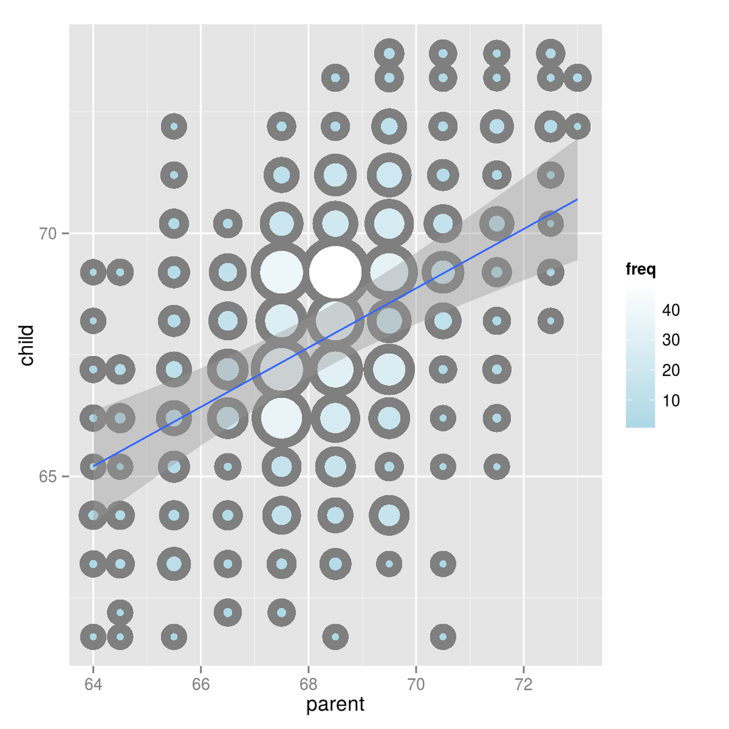